# Exploring General Social Survey Data in R

Michael Chirico

Compiled September 30, 2016 at 11:20

## Task 1 : Preliminaries

```r
library(data.table)
library(haven)

rm(list = ls(all = TRUE))
gc()
```

```
##          used (Mb) gc trigger (Mb) max used (Mb)
## Ncells 379574 20.3     750400 40.1   592000 31.7
## Vcells 572929  4.4    1308461 10.0   786305  6.0
```

```r
#setDT() converts the result to a data.table --
#  since read_dta is not part of the data.table
#  package, it returns the data as a data.frame,
#  which (in my opinion) is more of a pain to deal with
gss = setDT(read_dta("~/Dropbox/3/gss7210_r2_small.dta"))
```

`read_dta` keeps the variable label from Stata under a thing called an attribute of each variable. So, for example, the variable `racdin`, which has a sort of cryptic name, is actually much easier to understand by examining:

```r
gss[ , attr(racdin, "label")]
```

```
## [1] "object to opp. race home for dinner"
```

```r
#to view all of the atribute labels in the data set, do:
sapply(gss, attr, "label")
```

```
##                                                  year
## "gss year for this respondent                       "
##                                                  race
##                                  "race of respondent"
##                                                racmar
##              "favor law against racial intermarriage"
##                                              racmar10
##            "favor law against rac intrmar 10 yrs ago"
##                                                racdin
##                 "object to opp. race home for dinner"
##                                               racpush
##                                "blacks shouldnt push"
##                                                racseg
##              "whites have right to seg. neighborhood"
##                                               racopen
##                            "vote on open housing law"
##                                               raclive
##                       "any opp. race in neighborhood"
##                                               racclos
##                     "any opp. race living close to r"
##                                                racdis
##                       "how far are closest opp. race"
##                                              racinteg
##                  "will neighborhood become all black"
##                                              racobjct
##                 "neighborhood integrated by same ses"
##                                               rachome
##                  "opp. race home for dinner recently"
##                                              racschol
##            "should whites & blacks go to same school"
##                                                racfew
##               "children to school with opposite race"
##                                                rachaf
##               "children to school half opposite race"
##                                               racmost
##             "children to school mostly opposite race"
##                                               racpres
##                      "would vote for black president"
##                                                racjob
##                         "equal opportunities on jobs"
```

[output cut: 43 more lines]

```
##                          "racial makeup of workplace"
##                                              racpromo
##     "ethnic background makes your promotion differnt"
##                                              racrel12
##        "past 12 months r web to learn race relations"
##                                              racspeak
##              "allow racists to hold public meetings."
##                                              ractch15
##                 "allow racists to teach 15 yr. olds."
##                                                racpub
##                     "allow racists to publish books."
##                                               racists
##                   "feel about people who are racist."
##                                               racmeet
##            "allowed to hold pub meeting for racist  "
```

This is still a lot of information; to narrow things down, we’ll use a regular expression, which you can think of as a more powerful version of Googling. We’re looking for something about segregation – so presumably the variable label for any relevant variable will at the very least have the characters `"seg"` somewhere in it:

```r
grep("seg", sapply(gss, attr, "label"), value = TRUE)
```

```
##                                   racseg
## "whites have right to seg. neighborhood"
```

```r
#similarly, the one relevant to inter-racial marriage should
#  at a minimum contain the string "marr"
grep("marr", sapply(gss, attr, "label"), value = TRUE)
```

```
##                                   racmar
## "favor law against racial intermarriage"
```

```r
#Now that we've identified the relevant variables, we can explore them
gss[ , class(racseg)]
```

```
## [1] "labelled"
```

The `labelled` class is specific to the `haven` package. Look up the `?labelled` help file to learn more. The `"labels"` attribute tells us the mapping between the integer values the variable takes and what that integer stands for.

```r
gss[ , attr(racseg, "labels")]
```

```
##               iap    agree strongly    agree slightly disagree slightly
##                 0                 1                 2                 3
## disagree strongly                dk                na
##                 4                 8                 9
```

```r
gss[ , attr(racmar, "labels")]
```

```
## iap yes  no  dk  na
##   0   1   2   8   9
```

```r
## Once we know what the values stand for, the one-way table
##   will make sense once we see it:
gss[ , table(racseg)]
```

```
## racseg
##    1    2    3    4
## 2232 2689 4854 9776
```

```r
gss[ , table(racmar)]
```

```
## racmar
##     1     2
##  6629 22155
```

Note that there are >50,000 observations in the whole data set, but not nearly that many in these tables. That’s because these questions are plagued by extensive non-response; also, they simply weren’t asked in some years of the survey. To see the missing responses, use the `useNA` argument to `table`:

```r
gss[ , table(racseg, useNA = "ifany")]
```

```
## racseg
##     1     2     3     4  <NA>
##  2232  2689  4854  9776 35536
```

```r
gss[ , table(racmar, useNA = "ifany")]
```

```
## racmar
##     1     2  <NA>
##  6629 22155 26303
```

## Task 2 : Segregation

Given what we learned above, we’ll want to exclude non-respondents from our calculations; also, those who are anti-segregation correspond to those responding either `3` or `4` on `racseg`:

```r
gss[!is.na(racseg), anti_segregation :=
      racseg %in% c(3, 4)]
```

## Task 3: Interracial Marriage

Defining support for interracial marriage is nearly identical:

```r
gss[!is.na(racmar), pro_interracial_marriage := racmar == 2]
```

## Task 4: Averages by Year

Luckily the year of the observation is simply stored in the variable `year`. Remembering that there are many missing observations in each of our indicators, we’ll have to use the `na.rm` argument to handle these. By default, R returns `NA` if we try and take the mean of any variable that has a missing observation; if we set `na.rm = TRUE`, R will exclude all of the missing rows and take the average of the remaining rows.

```r
#.(a = mean(b)) will return a column named "a" which
#  is equal to the mean of the column b.
gss[ , .(pct_anti_segregation =
           mean(anti_segregation, na.rm = TRUE),
         pct_pro_interracial_marriage =
           mean(pro_interracial_marriage, na.rm = TRUE)),
     #recall that we use keyby to be sure the output is sorted.
     keyby = year]
```

```
##     year pct_anti_segregation pct_pro_interracial_marriage
##  1: 1972            0.5985634                    0.6073338
##  2: 1973                  NaN                    0.6214119
##  3: 1974                  NaN                    0.6546875
##  4: 1975                  NaN                    0.6137771
##  5: 1976            0.6073298                    0.6744361
##  6: 1977            0.5760122                    0.7174077
##  7: 1978                  NaN                          NaN
##  8: 1980            0.6881188                    0.7007708
##  9: 1982            0.7567419                    0.7430633
## 10: 1983                  NaN                          NaN
## 11: 1984            0.7477352                    0.7498192
## 12: 1985            0.7478144                    0.7395693
## 13: 1986                  NaN                          NaN
## 14: 1987            0.7939189                    0.7897727
## 15: 1988            0.7789474                    0.7746032
## 16: 1989            0.7862138                    0.7868526
## 17: 1990            0.7767756                    0.8078652
## 18: 1991            0.8229814                    0.8238994
## 19: 1993            0.8561905                    0.8283510
## 20: 1994            0.8464304                    0.8622816
## 21: 1996            0.8817787                    0.8888889
## 22: 1998                  NaN                    0.8884636
## 23: 2000                  NaN                    0.8986447
## 24: 2002                  NaN                    0.9039301
## 25: 2004                  NaN                          NaN
## 26: 2006                  NaN                          NaN
## 27: 2008                  NaN                          NaN
## 28: 2010                  NaN                          NaN
##     year pct_anti_segregation pct_pro_interracial_marriage
```

## Task 5: Plot

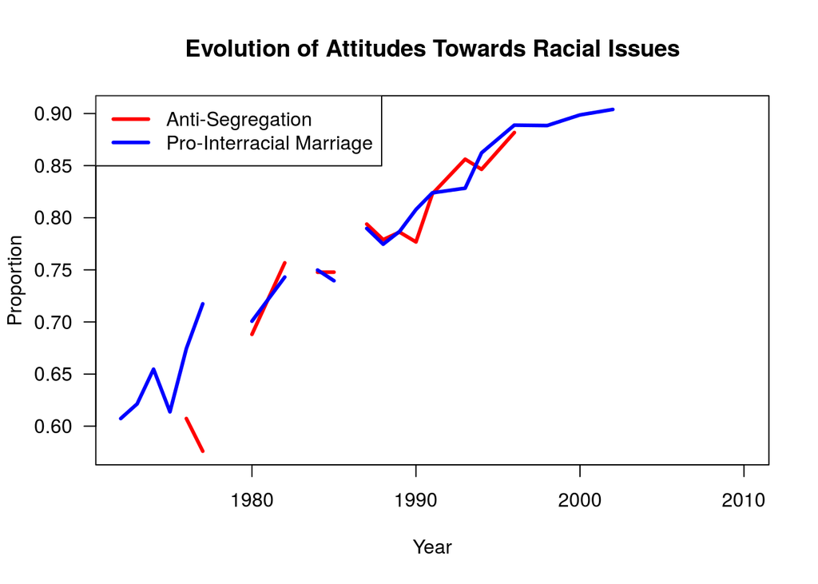

```r
#the first part is just a copy-paste of the
#  answer to the prior task
gss[ , .(pct_anti_segregation =
           mean(anti_segregation, na.rm = TRUE),
         pct_pro_interracial_marriage =
           mean(pro_interracial_marriage, na.rm = TRUE)),
     #we take the result of the earlier task, and perform
     #  more calculations on the result by adding a
     #  second pair of square braces; the second pair of
     #  square braces allows us to access the results of
     #  the first pair of square braces.
     keyby = year][ , {
       #see ?matplot
       matplot(year, cbind(pct_anti_segregation,
                           pct_pro_interracial_marriage),
               main = "Evolution of Attitudes Towards Racial Issues",
               xlab = "Year", ylab = "Proportion", las = 1L,
               type = "l", lwd = 3L, lty = 1L, col = c("red", "blue"))
       legend("topleft", legend = c("Anti-Segregation",
                                    "Pro-Interracial Marriage"),
              col = c("red", "blue"), lty = 1L, lwd = 3L)}]
```